# Cyclist Estudo de Caso

Shaini

2025-09-16

Este trabalho consiste na conclusão do curso “Google Data Analytics” da Coursera, no qual realizamos um estudo de caso sobre a empresa fictícia Cyclistic Bike-Share, um programa de compartilhamento de bicicletas em Chicago.

O objetivo principal é analisar o comportamento de usuários casuais e membros anuais, gerando insights que possam orientar estratégias de marketing para aumentar a adesão a assinaturas anuais.

Para esta análise, optou-se por utilizar apenas os dados do primeiro trimestre de 2019 e do primeiro trimestre de 2020, seguindo a recomendação do curso e considerando as limitações de armazenamento de dados e desempenho do RStudio Desktop.

A metodologia adotada inclui:

**R** – para limpeza, preparação e análise exploratória dos dados; **Tableau** – para criar visualizações interativas e gráficos detalhados, que facilitam a interpretação dos insights e a apresentação dos resultados.

Esta abordagem permite demonstrar tanto habilidades técnicas em análise de dados quanto capacidade de comunicar resultados de forma visual e estratégica.

```r
library(tidyverse)
```

```r
library(readr)
library(ggplot2)
library(dplyr)
library(scales)
#Livrarias recomendadas
library(conflicted)
```

```r
# Set dplyr::filter and dplyr::lag as the default choices
conflict_prefer("filter", "dplyr")
```

```
## [conflicted] Will prefer dplyr::filter over any other package.
```

```r
conflict_prefer("lag", "dplyr")
```

```
## [conflicted] Will prefer dplyr::lag over any other package.
```

#===================== # STEP 1: COLLECT DATA #=====================

```r
#Importando dados de 2019
q1_2019 <- read_csv("C:/Users/shain/Documents/Cyclist Estudo de Caso/Divvy_Trips_2019_Q1.csv")
#Visualizando o meu dataset
head(q1_2019)
```

```
## # A tibble: 6 × 12
##    trip_id start_time         end_time       bikeid tripduration from_station_id
##      <dbl> <chr>              <chr>           <dbl>        <dbl>           <dbl>
## 1 21742443 2019-01-01 0:04:37 2019-01-01 0:…   2167          390             199
## 2 21742444 2019-01-01 0:08:13 2019-01-01 0:…   4386          441              44
## 3 21742445 2019-01-01 0:13:23 2019-01-01 0:…   1524          829              15
## 4 21742446 2019-01-01 0:13:45 2019-01-01 0:…    252         1783             123
## 5 21742447 2019-01-01 0:14:52 2019-01-01 0:…   1170          364             173
## 6 21742448 2019-01-01 0:15:33 2019-01-01 0:…   2437          216              98
## # ℹ 6 more variables: from_station_name <chr>, to_station_id <dbl>,
## #   to_station_name <chr>, usertype <chr>, gender <chr>, birthyear <dbl>
```

```r
#Importando dados de 2020
q1_2020 <- read_csv("C:/Users/shain/Documents/Cyclist Estudo de Caso/Divvy_Trips_2020_Q1.csv")
colnames(q1_2020)
```

```
##  [1] "ride_id"            "rideable_type"      "started_at"
##  [4] "ended_at"           "start_station_name" "start_station_id"
##  [7] "end_station_name"   "end_station_id"     "start_lat"
## [10] "start_lng"          "end_lat"            "end_lng"
## [13] "member_casual"
```

```r
# Verificando o intervalo de datas da coluna started_at
min(q1_2019$start_time)
```

```
## [1] "2019-01-01 0:04:37"
```

```r
max(q1_2019$start_time)
```

```
## [1] "2019-03-31 9:59:31"
```

#==================================================== # STEP 2: WRANGLE DATA AND COMBINE INTO A SINGLE FILE #====================================================

```r
#Renomeando o nome das colunas de q1_2019
(q1_2019 <- rename(q1_2019,
                   ride_id=trip_id,
                   started_at=start_time,
                   ended_at=end_time,
                   start_station_name=from_station_name,
                   end_station_name=to_station_name,
                   start_station_id=from_station_id,
                   end_station_id=to_station_id,
                   member_casual=usertype))
```

```
## # A tibble: 365,069 × 12
##     ride_id started_at         ended_at     bikeid tripduration start_station_id
##       <dbl> <chr>              <chr>         <dbl>        <dbl>            <dbl>
##  1 21742443 2019-01-01 0:04:37 2019-01-01 …   2167          390              199
##  2 21742444 2019-01-01 0:08:13 2019-01-01 …   4386          441               44
##  3 21742445 2019-01-01 0:13:23 2019-01-01 …   1524          829               15
##  4 21742446 2019-01-01 0:13:45 2019-01-01 …    252         1783              123
##  5 21742447 2019-01-01 0:14:52 2019-01-01 …   1170          364              173
##  6 21742448 2019-01-01 0:15:33 2019-01-01 …   2437          216               98
##  7 21742449 2019-01-01 0:16:06 2019-01-01 …   2708          177               98
##  8 21742450 2019-01-01 0:18:41 2019-01-01 …   2796          100              211
##  9 21742451 2019-01-01 0:18:43 2019-01-01 …   6205         1727              150
## 10 21742452 2019-01-01 0:19:18 2019-01-01 …   3939          336              268
## # ℹ 365,059 more rows
## # ℹ 6 more variables: start_station_name <chr>, end_station_id <dbl>,
## #   end_station_name <chr>, member_casual <chr>, gender <chr>, birthyear <dbl>
```

```r
# Inspecione o dataframe e procure inconsistências
str(q1_2019)
```

```
## spc_tbl_ [365,069 × 12] (S3: spec_tbl_df/tbl_df/tbl/data.frame)
##  $ ride_id           : num [1:365069] 21742443 21742444 21742445 21742446 21742447 ...
##  $ started_at        : chr [1:365069] "2019-01-01 0:04:37" "2019-01-01 0:08:13" "2019-01-01 0:13:23" "2019-01-01 0:13:45" ...
##  $ ended_at          : chr [1:365069] "2019-01-01 0:11:07" "2019-01-01 0:15:34" "2019-01-01 0:27:12" "2019-01-01 0:43:28" ...
##  $ bikeid            : num [1:365069] 2167 4386 1524 252 1170 ...
##  $ tripduration      : num [1:365069] 390 441 829 1783 364 ...
##  $ start_station_id  : num [1:365069] 199 44 15 123 173 98 98 211 150 268 ...
##  $ start_station_name: chr [1:365069] "Wabash Ave & Grand Ave" "State St & Randolph St" "Racine Ave & 18th St" "California Ave & Milwaukee Ave" ...
##  $ end_station_id    : num [1:365069] 84 624 644 176 35 49 49 142 148 141 ...
##  $ end_station_name  : chr [1:365069] "Milwaukee Ave & Grand Ave" "Dearborn St & Van Buren St (*)" "Western Ave & Fillmore St (*)" "Clark St & Elm St" ...
##  $ member_casual     : chr [1:365069] "Subscriber" "Subscriber" "Subscriber" "Subscriber" ...
##  $ gender            : chr [1:365069] "Male" "Female" "Female" "Male" ...
##  $ birthyear         : num [1:365069] 1989 1990 1994 1993 1994 ...
##  - attr(*, "spec")=
##   .. cols(
##   ..   trip_id = col_double(),
##   ..   start_time = col_character(),
##   ..   end_time = col_character(),
##   ..   bikeid = col_double(),
##   ..   tripduration = col_number(),
##   ..   from_station_id = col_double(),
##   ..   from_station_name = col_character(),
##   ..   to_station_id = col_double(),
##   ..   to_station_name = col_character(),
##   ..   usertype = col_character(),
##   ..   gender = col_character(),
##   ..   birthyear = col_double()
##   .. )
##  - attr(*, "problems")=<externalptr>
```

```r
str(q1_2020)
```

```
## spc_tbl_ [426,887 × 13] (S3: spec_tbl_df/tbl_df/tbl/data.frame)
##  $ ride_id           : chr [1:426887] "EACB19130B0CDA4A" "8FED874C809DC021" "789F3C21E472CA96" "C9A388DAC6ABF313" ...
##  $ rideable_type     : chr [1:426887] "docked_bike" "docked_bike" "docked_bike" "docked_bike" ...
##  $ started_at        : chr [1:426887] "2020-01-21 20:06:59" "2020-01-30 14:22:39" "2020-01-09 19:29:26" "2020-01-06 16:17:07" ...
##  $ ended_at          : chr [1:426887] "2020-01-21 20:14:30" "2020-01-30 14:26:22" "2020-01-09 19:32:17" "2020-01-06 16:25:56" ...
##  $ start_station_name: chr [1:426887] "Western Ave & Leland Ave" "Clark St & Montrose Ave" "Broadway & Belmont Ave" "Clark St & Randolph St" ...
##  $ start_station_id  : num [1:426887] 239 234 296 51 66 212 96 96 212 38 ...
##  $ end_station_name  : chr [1:426887] "Clark St & Leland Ave" "Southport Ave & Irving Park Rd" "Wilton Ave & Belmont Ave" "Fairbanks Ct & Grand Ave" ...
##  $ end_station_id    : num [1:426887] 326 318 117 24 212 96 212 212 96 100 ...
##  $ start_lat         : num [1:426887] 42 42 41.9 41.9 41.9 ...
##  $ start_lng         : num [1:426887] -87.7 -87.7 -87.6 -87.6 -87.6 ...
##  $ end_lat           : num [1:426887] 42 42 41.9 41.9 41.9 ...
##  $ end_lng           : num [1:426887] -87.7 -87.7 -87.7 -87.6 -87.6 ...
##  $ member_casual     : chr [1:426887] "member" "member" "member" "member" ...
##  - attr(*, "spec")=
##   .. cols(
##   ..   ride_id = col_character(),
##   ..   rideable_type = col_character(),
##   ..   started_at = col_character(),
##   ..   ended_at = col_character(),
##   ..   start_station_name = col_character(),
##   ..   start_station_id = col_double(),
##   ..   end_station_name = col_character(),
##   ..   end_station_id = col_double(),
##   ..   start_lat = col_double(),
##   ..   start_lng = col_double(),
##   ..   end_lat = col_double(),
##   ..   end_lng = col_double(),
##   ..   member_casual = col_character()
##   .. )
##  - attr(*, "problems")=<externalptr>
```

Verificou-se que na dataset de 2019 a unidade da coluna ‘ride_id’ está em números e de 2020 está em caracteres. Preferimos usar o padrão da tabela 2020.

```r
q1_2019 <- mutate(q1_2019, ride_id=as.character(ride_id))
```

```r
#Juntando os dois dataframe em um só

all_trips <- bind_rows(q1_2019, q1_2020)
```

Nota sobre as colunas bikeid e rideable_type: As colunas bikeid (2019) e rideable_type (2020) não foram associadas nem usadas na análise porque representam informações diferentes. Além do que, viu-se que não são informações necessárias para essa análise em específico.

- **bikeid** identifica cada bicicleta individualmente como número, permitindo rastrear cada unidade em 2019.
- **rideable_type** em 2020 apresenta apenas “docked_bike” para todas as viagens, sem distinção entre bicicletas.

```r
#Vendo os valores diferentes da coluna 'rideable_type'
unique(q1_2020$rideable_type)
```

```
## [1] "docked_bike"
```

```r
#Verificando quantas vezes cada valor aparece
table(q1_2020$rideable_type)
```

```
##
## docked_bike
##      426887
```

Como não há correspondência direta entre essas colunas nos dois anos, incluí-las poderia gerar confusão ou resultados incorretos. Por isso, foram excluídas do dataset final para focar na análise de comportamento de usuários casuais versus membros anuais. Além disso, exclui-se outras colunas que não possuem correspondencia, nomeadamente latitude (inicial e final), gênero, longitute(inicial e final) e ano de nascimento.

```r
#Removendo colunas que não me servem
all_trips <- all_trips %>%
  select(-c(bikeid, tripduration,gender, rideable_type,start_lat, start_lng, end_lat, end_lng, birthyear))

head(all_trips)
```

```
## # A tibble: 6 × 8
##   ride_id started_at ended_at start_station_id start_station_name end_station_id
##   <chr>   <chr>      <chr>               <dbl> <chr>                       <dbl>
## 1 217424… 2019-01-0… 2019-01…              199 Wabash Ave & Gran…             84
## 2 217424… 2019-01-0… 2019-01…               44 State St & Randol…            624
## 3 217424… 2019-01-0… 2019-01…               15 Racine Ave & 18th…            644
## 4 217424… 2019-01-0… 2019-01…              123 California Ave & …            176
## 5 217424… 2019-01-0… 2019-01…              173 Mies van der Rohe…             35
## 6 217424… 2019-01-0… 2019-01…               98 LaSalle St & Wash…             49
## # ℹ 2 more variables: end_station_name <chr>, member_casual <chr>
```

#====================================================== # STEP 3: CLEAN UP AND ADD DATA TO PREPARE FOR ANALYSIS #====================================================== # Inspect the new table that has been created

```r
colnames(all_trips)  #List of column names
```

```
## [1] "ride_id"            "started_at"         "ended_at"
## [4] "start_station_id"   "start_station_name" "end_station_id"
## [7] "end_station_name"   "member_casual"
```

```r
nrow(all_trips)  #How many rows are in data frame?
```

```
## [1] 791956
```

```r
dim(all_trips)  #Dimensions of the data frame?
```

```
## [1] 791956      8
```

```r
head(all_trips)  #See the first 6 rows of data frame.  Also tail(all_trips)
```

```
## # A tibble: 6 × 8
##   ride_id started_at ended_at start_station_id start_station_name end_station_id
##   <chr>   <chr>      <chr>               <dbl> <chr>                       <dbl>
## 1 217424… 2019-01-0… 2019-01…              199 Wabash Ave & Gran…             84
## 2 217424… 2019-01-0… 2019-01…               44 State St & Randol…            624
## 3 217424… 2019-01-0… 2019-01…               15 Racine Ave & 18th…            644
## 4 217424… 2019-01-0… 2019-01…              123 California Ave & …            176
## 5 217424… 2019-01-0… 2019-01…              173 Mies van der Rohe…             35
## 6 217424… 2019-01-0… 2019-01…               98 LaSalle St & Wash…             49
## # ℹ 2 more variables: end_station_name <chr>, member_casual <chr>
```

```r
str(all_trips)  #See list of columns and data types (numeric, character, etc)
```

```
## tibble [791,956 × 8] (S3: tbl_df/tbl/data.frame)
##  $ ride_id           : chr [1:791956] "21742443" "21742444" "21742445" "21742446" ...
##  $ started_at        : chr [1:791956] "2019-01-01 0:04:37" "2019-01-01 0:08:13" "2019-01-01 0:13:23" "2019-01-01 0:13:45" ...
##  $ ended_at          : chr [1:791956] "2019-01-01 0:11:07" "2019-01-01 0:15:34" "2019-01-01 0:27:12" "2019-01-01 0:43:28" ...
##  $ start_station_id  : num [1:791956] 199 44 15 123 173 98 98 211 150 268 ...
##  $ start_station_name: chr [1:791956] "Wabash Ave & Grand Ave" "State St & Randolph St" "Racine Ave & 18th St" "California Ave & Milwaukee Ave" ...
##  $ end_station_id    : num [1:791956] 84 624 644 176 35 49 49 142 148 141 ...
##  $ end_station_name  : chr [1:791956] "Milwaukee Ave & Grand Ave" "Dearborn St & Van Buren St (*)" "Western Ave & Fillmore St (*)" "Clark St & Elm St" ...
##  $ member_casual     : chr [1:791956] "Subscriber" "Subscriber" "Subscriber" "Subscriber" ...
```

```r
summary(all_trips)  #Statistical summary of data. Mainly for numerics
```

```
##    ride_id           started_at          ended_at         start_station_id
##  Length:791956      Length:791956      Length:791956      Min.   :  2.0
##  Class :character   Class :character   Class :character   1st Qu.: 77.0
##  Mode  :character   Mode  :character   Mode  :character   Median :174.0
##                                                           Mean   :204.4
##                                                           3rd Qu.:291.0
##                                                           Max.   :675.0
##
##  start_station_name end_station_id  end_station_name   member_casual
##  Length:791956      Min.   :  2.0   Length:791956      Length:791956
##  Class :character   1st Qu.: 77.0   Class :character   Class :character
##  Mode  :character   Median :174.0   Mode  :character   Mode  :character
##                     Mean   :204.4
##                     3rd Qu.:291.0
##                     Max.   :675.0
##                     NA's   :1
```

```r
#Verificando a coluna member_casual
unique(all_trips$member_casual)
```

```
## [1] "Subscriber" "Customer"   "member"     "casual"
```

```r
table(all_trips$member_casual)
```

```
##
##     casual   Customer     member Subscriber
##      48480      23163     378407     341906
```

```r
#case_when(
  #condição1 ~ valor1,
  #condição2 ~ valor2,
  #condição3 ~ valor3,
  #TRUE       ~ valor_default  # opcional
#)
```

```r
#Mudando 'Subscriber' para 'member' e 'Customer' para 'casual'
all_trips <- all_trips %>%
  mutate(member_casual = case_when(
    member_casual %in% c("Customer", "casual") ~ "casual",
    member_casual %in% c("Subscriber", "member") ~ "member"
  ) )
```

Desmembrando data, ano, mês, dia, dia da semana e hora. Lembrando que o formato está “2019-01-01 0:04:37”

```r
#Criando colunas desmembrando data, ano, dia, mes, dia da semana e hora.
#all_trips <- all_trips %>%
  #mutate(
    #start_date=as.Date(started_at),
    #start_day=day(started_at),
    #start_month=month(started_at),
    #start_year=year(started_at),
    #start_wday= wday(started_at, label=TRUE),

    #end_date=as.Date(ended_at),
    #end_day=day(ended_at),
    #end_month=month(ended_at),
    #end_year=year(ended_at),
    #end_wday= wday(ended_at, label=TRUE)

    #)
```

```r
all_trips$date <- as.Date(all_trips$started_at) #The default format is yyyy-mm-dd
all_trips$month <- format(as.Date(all_trips$date), "%m")
all_trips$day <- format(as.Date(all_trips$date), "%d")
all_trips$year <- format(as.Date(all_trips$date), "%Y")
all_trips$day_of_week <- format(as.Date(all_trips$date), "%A")
```

A primeira vez fiz a conversão de maneira equivocada, o que me deu resultados muito errados no tempo de duração da corrida (mais de 90% do meu trip_duration ficou ZERADO).  
Ao analisar o formato de ‘started_at’ e ‘ended_at’, verificou-se o formato de characteres. Ou seja, é necessário mudar isso para **POSIXct** ou **POSIXlt**, uma vez que characteres não vai fazer a contagem da diferença de tempo.

```r
all_trips$started_at <- as.POSIXct(all_trips$started_at, format = "%Y-%m-%d %H:%M:%S")
all_trips$ended_at   <- as.POSIXct(all_trips$ended_at,   format = "%Y-%m-%d %H:%M:%S")

all_trips$ride_length <- difftime(all_trips$ended_at, all_trips$started_at, unit="secs")
```

✅ Resumindo: a s.character → só texto, não faz cálculo. as.Date → só data (perde hora). as.POSIXct → data + hora (certo para calcular duração).

```r
all_trips$ride_length <- as.numeric(all_trips$ride_length, units = "mins")
head(all_trips)
```

```
## # A tibble: 6 × 14
##   ride_id  started_at          ended_at            start_station_id
##   <chr>    <dttm>              <dttm>                         <dbl>
## 1 21742443 2019-01-01 00:04:37 2019-01-01 00:11:07              199
## 2 21742444 2019-01-01 00:08:13 2019-01-01 00:15:34               44
## 3 21742445 2019-01-01 00:13:23 2019-01-01 00:27:12               15
## 4 21742446 2019-01-01 00:13:45 2019-01-01 00:43:28              123
## 5 21742447 2019-01-01 00:14:52 2019-01-01 00:20:56              173
## 6 21742448 2019-01-01 00:15:33 2019-01-01 00:19:09               98
## # ℹ 10 more variables: start_station_name <chr>, end_station_id <dbl>,
## #   end_station_name <chr>, member_casual <chr>, date <date>, month <chr>,
## #   day <chr>, year <chr>, day_of_week <chr>, ride_length <dbl>
```

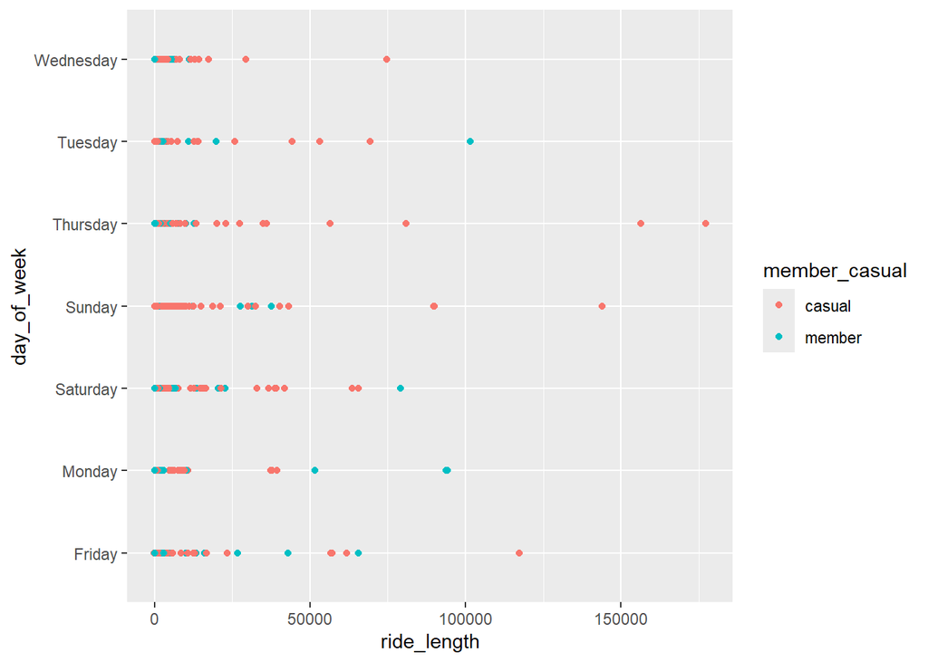

```r
library(ggplot2)

ggplot(data=all_trips, aes(x=ride_length, day_of_week, color=member_casual)) + geom_point()
```

```r
sum(all_trips$ride_length == 0, na.rm = TRUE)
```

```
## [1] 93
```

```r
table(all_trips$member_casual)
```

```
##
## casual member
##  71643 720313
```

```r
all_trips_v2 <- all_trips[!(all_trips$start_station_name == "HQ QR" | all_trips$ride_length<=0),]

head(all_trips_v2)
```

```
## # A tibble: 6 × 14
##   ride_id  started_at          ended_at            start_station_id
##   <chr>    <dttm>              <dttm>                         <dbl>
## 1 21742443 2019-01-01 00:04:37 2019-01-01 00:11:07              199
## 2 21742444 2019-01-01 00:08:13 2019-01-01 00:15:34               44
## 3 21742445 2019-01-01 00:13:23 2019-01-01 00:27:12               15
## 4 21742446 2019-01-01 00:13:45 2019-01-01 00:43:28              123
## 5 21742447 2019-01-01 00:14:52 2019-01-01 00:20:56              173
## 6 21742448 2019-01-01 00:15:33 2019-01-01 00:19:09               98
## # ℹ 10 more variables: start_station_name <chr>, end_station_id <dbl>,
## #   end_station_name <chr>, member_casual <chr>, date <date>, month <chr>,
## #   day <chr>, year <chr>, day_of_week <chr>, ride_length <dbl>
```

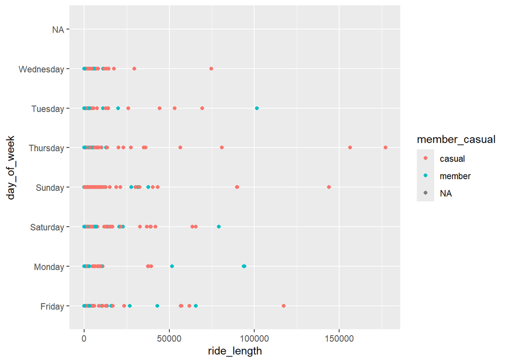

```r
ggplot(data=all_trips_v2, aes(x=ride_length, day_of_week, color=member_casual)) + geom_point()
```

```r
table(all_trips_v2$ride_length)
```

[output not shown]

[output cut: 4966 more lines]

[output not shown]

#Brincar novamente com o ride_length pq agora não consigo fazer cálculos como media, mediana, max e min. Isso tem a ver com o formato POSIXct e NUMERIC. Isso será cenas dos próximos capítulos.

#===================================== # STEP 4: CONDUCT DESCRIPTIVE ANALYSIS #=====================================

```r
mean(all_trips_v2$ride_length) #straight average (total ride length / rides)
```

```
## [1] NA
```

```r
median(all_trips_v2$ride_length) #midpoint number in the ascending array of ride lengths
```

```
## [1] NA
```

```r
max(all_trips_v2$ride_length) #longest ride
```

```
## [1] NA
```

```r
min(all_trips_v2$ride_length) #shortest ride
```

```
## [1] NA
```

```r
head(all_trips_v2)
```

```
## # A tibble: 6 × 14
##   ride_id  started_at          ended_at            start_station_id
##   <chr>    <dttm>              <dttm>                         <dbl>
## 1 21742443 2019-01-01 00:04:37 2019-01-01 00:11:07              199
## 2 21742444 2019-01-01 00:08:13 2019-01-01 00:15:34               44
## 3 21742445 2019-01-01 00:13:23 2019-01-01 00:27:12               15
## 4 21742446 2019-01-01 00:13:45 2019-01-01 00:43:28              123
## 5 21742447 2019-01-01 00:14:52 2019-01-01 00:20:56              173
## 6 21742448 2019-01-01 00:15:33 2019-01-01 00:19:09               98
## # ℹ 10 more variables: start_station_name <chr>, end_station_id <dbl>,
## #   end_station_name <chr>, member_casual <chr>, date <date>, month <chr>,
## #   day <chr>, year <chr>, day_of_week <chr>, ride_length <dbl>
```

Apesar de ter tranformado ride_length para as.numeric, ainda não consigo calcular media, mediana, máximos e mínimos, os resultados são ‘NA’. Vou verificar a existencia de NA na coluna “ride_lenght’.

```r
any(is.na(all_trips_v2$ride_length))
```

```
## [1] TRUE
```

```r
sum(is.na(all_trips_v2$ride_length))
```

```
## [1] 36
```

```r
all_trips_v2 <- all_trips[
  !(all_trips$start_station_name == "HQ QR" |
    all_trips$ride_length < 0 |
    is.na(all_trips$ride_length)),
]
```

```r
summary(all_trips_v2$ride_length)
```

```
##      Min.   1st Qu.    Median      Mean   3rd Qu.      Max.
## 1.700e-02 5.517e+00 8.983e+00 1.982e+01 1.520e+01 1.771e+05
```

```r
all_trips_v2 <- all_trips_v2[!(all_trips_v2$ride_length >84600),]
```

```r
#aggregate(variável ~ grupo, FUN = função)
```

Calcula a média/mediana/máx./min do ride_length para cada grupo de usuários (“member” e “casual”).

```r
aggregate(all_trips_v2$ride_length ~ all_trips_v2$member_casual, FUN = mean)
```

```
##   all_trips_v2$member_casual all_trips_v2$ride_length
## 1                     casual                 78.11939
## 2                     member                 12.85113
```

```r
aggregate(all_trips_v2$ride_length ~ all_trips_v2$member_casual, FUN = median)
```

```
##   all_trips_v2$member_casual all_trips_v2$ride_length
## 1                     casual                23.216667
## 2                     member                 8.466667
```

```r
aggregate(all_trips_v2$ride_length ~ all_trips_v2$member_casual, FUN = max)
```

```
##   all_trips_v2$member_casual all_trips_v2$ride_length
## 1                     casual                 80991.13
## 2                     member                 79157.52
```

```r
aggregate(all_trips_v2$ride_length ~ all_trips_v2$member_casual, FUN = min)
```

```
##   all_trips_v2$member_casual all_trips_v2$ride_length
## 1                     casual               0.03333333
## 2                     member               0.01666667
```

```r
mean_ride <- aggregate(all_trips_v2$ride_length ~ all_trips_v2$member_casual, FUN = mean)
median_ride <- aggregate(all_trips_v2$ride_length ~ all_trips_v2$member_casual, FUN = median)
max_ride <- aggregate(all_trips_v2$ride_length ~ all_trips_v2$member_casual, FUN = max)
min_ride <- aggregate(all_trips_v2$ride_length ~ all_trips_v2$member_casual, FUN = min)
```

Vendo a média por dia da semana para cada tipo de membro

```r
aggregate(all_trips_v2$ride_length~all_trips_v2$member_casual + all_trips_v2$day_of_week, FUN=mean)
```

```
##    all_trips_v2$member_casual all_trips_v2$day_of_week all_trips_v2$ride_length
## 1                      casual                   Friday                 86.83656
## 2                      member                   Friday                 13.27733
## 3                      casual                   Monday                 79.19011
## 4                      member                   Monday                 12.00336
## 5                      casual                 Saturday                 82.45941
## 6                      member                 Saturday                 16.22849
## 7                      casual                   Sunday                 67.02062
## 8                      member                   Sunday                 16.21671
## 9                      casual                 Thursday                 94.15306
## 10                     member                 Thursday                 11.78634
## 11                     casual                  Tuesday                 76.01365
## 12                     member                  Tuesday                 12.02969
## 13                     casual                Wednesday                 74.66507
## 14                     member                Wednesday                 11.86541
```

```r
# Analyze ridership data by type and weekday
all_trips_v2 %>%
  mutate(weekday = wday(started_at, label = TRUE)) %>%  # cria coluna com o dia da semana
  group_by(member_casual, weekday) %>%  # agrupa por tipo de usuário e dia da semana
  summarise(
    number_of_rides = n(),  # conta o número de viagens
    average_duration = mean(ride_length, na.rm = TRUE)  # calcula a média de duração sem NA
  ) %>%
  arrange(member_casual, weekday)  # ordena
```

```
## # A tibble: 14 × 4
## # Groups:   member_casual [2]
##    member_casual weekday number_of_rides average_duration
##    <chr>         <ord>             <int>            <dbl>
##  1 casual        Sun               18642             67.0
##  2 casual        Mon                5591             79.2
##  3 casual        Tue                7311             76.0
##  4 casual        Wed                7690             74.7
##  5 casual        Thu                7145             94.2
##  6 casual        Fri                8012             86.8
##  7 casual        Sat               13473             82.5
##  8 member        Sun               60168             16.2
##  9 member        Mon              110428             12.0
## 10 member        Tue              127973             12.0
## 11 member        Wed              121902             11.9
## 12 member        Thu              125228             11.8
## 13 member        Fri              115168             13.3
## 14 member        Sat               59413             16.2
```

Mesma coisa do código anterior só que acrescenta um gráfico:

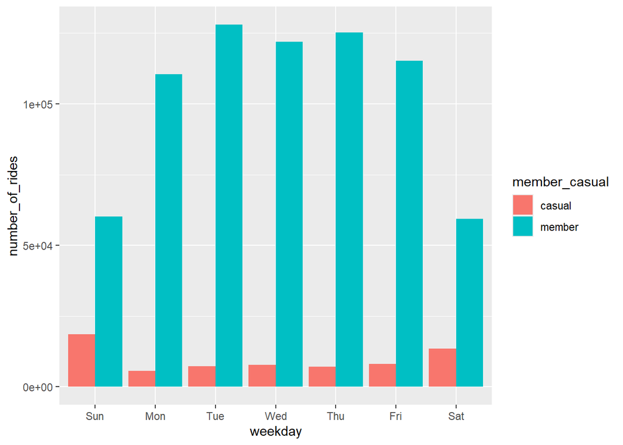

```r
all_trips_v2 %>%
  mutate(weekday = wday(started_at, label = TRUE)) %>%
  group_by(member_casual, weekday) %>%
  summarise(number_of_rides = n()
            ,average_duration = mean(ride_length)) %>%
  arrange(member_casual, weekday)  %>%
  ggplot(aes(x = weekday, y = number_of_rides, fill = member_casual)) +
  geom_col(position = "dodge")
```

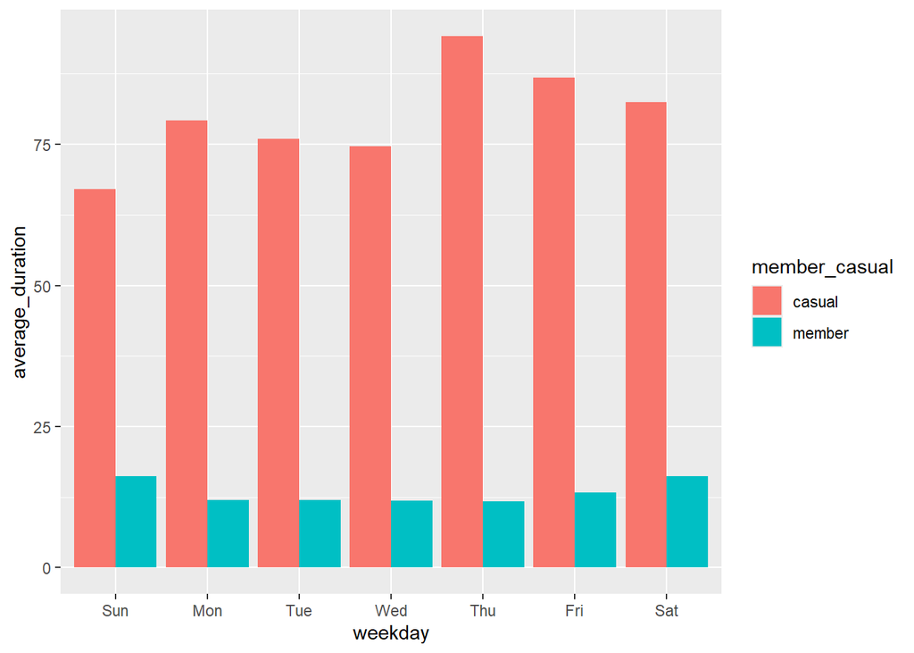

```r
all_trips_v2 %>%
  mutate(weekday = wday(started_at, label = TRUE)) %>%
  group_by(member_casual, weekday) %>%
  summarise(number_of_rides = n()
            ,average_duration = mean(ride_length)) %>%
  arrange(member_casual, weekday)  %>%
  ggplot(aes(x = weekday, y = average_duration, fill = member_casual)) +
  geom_col(position = "dodge")
```

Importando para arquivo.csv

```r
counts <- aggregate(all_trips_v2$ride_length ~ all_trips_v2$member_casual + all_trips_v2$day_of_week, FUN = mean)

write.csv(counts, file = "C:/Users/shain/Documents/Cyclist Estudo de Caso/avg_ride_length.csv", row.names = FALSE)
```

```r
library(dplyr)

counts <- all_trips_v2 %>%
  group_by(member_casual, day_of_week) %>%
  summarise(
    avg_duration = mean(ride_length),
    total_rides = n()
  )
write.csv(counts, file = "C:/Users/shain/Documents/Cyclist Estudo de Caso/avg_ride_length_v2.csv", row.names = FALSE)
```